# Titanic: Machine Learning from Disaster

```r
installpaxs<-data.frame(installed.packages())
ifelse(any(installpaxs$Package=="dplyr")==FALSE,install.packages("dplyr"),library(dplyr))
```

```
[1] "caret"
```

```r
library(dplyr)
ifelse(any(installpaxs$Package=="naniar")==FALSE,install.packages("naniar"),library(naniar))
```

```
[1] "caret"
```

```r
library(naniar)
ifelse(any(installpaxs$Package=="ggplot2")==FALSE,install.packages("ggplot2"),library(ggplot2))
```

```
[1] "caret"
```

```r
library(ggplot2)
ifelse(any(installpaxs$Package=="reshape")==FALSE,install.packages("reshape"),library(reshape))
```

```
[1] "caret"
```

```r
library(reshape)
ifelse(any(installpaxs$Package=="scales")==FALSE,install.packages("scales"),library(scales))
```

```
[1] "caret"
```

```r
library(scales)
ifelse(any(installpaxs$Package=="randomForest")==FALSE,install.packages("randomForest"),library(randomForest))
```

```
[1] "caret"
```

```r
library(randomForest)
ifelse(any(installpaxs$Package=="pROC")==FALSE,install.packages("pROC"),library(pROC))
```

```
[1] "pROC"
```

```r
library(pROC)
```

The required analysis is to predict the number of deaths in a similar data using the number of deaths from the Titanic disaster.

```r
getwd()
```

```
[1] "C:/Users/admin/Documents/Titanic Case Study"
```

```r
setwd(dirname(rstudioapi::getActiveDocumentContext()$path))
gender_submission<-read.csv("gender_submission.csv")
test<-read.csv("test.csv")
train<-read.csv("train.csv")
```

The data is loaded on R and we get an overview of the data.The first thing required is understand the dimension of the dataset provided.

```r
#Analysis train
dim_desc(train)
```

```
[1] "[891 x 12]"
```

```r
str(train)
```

```
'data.frame':   891 obs. of  12 variables:
 $ PassengerId: int  1 2 3 4 5 6 7 8 9 10 ...
 $ Survived   : int  0 1 1 1 0 0 0 0 1 1 ...
 $ Pclass     : int  3 1 3 1 3 3 1 3 3 2 ...
 $ Name       : Factor w/ 891 levels "Abbing, Mr. Anthony",..: 109 191 358 277 16 559 520 629 417 581 ...
 $ Sex        : Factor w/ 2 levels "female","male": 2 1 1 1 2 2 2 2 1 1 ...
 $ Age        : num  22 38 26 35 35 NA 54 2 27 14 ...
 $ SibSp      : int  1 1 0 1 0 0 0 3 0 1 ...
 $ Parch      : int  0 0 0 0 0 0 0 1 2 0 ...
 $ Ticket     : Factor w/ 681 levels "110152","110413",..: 524 597 670 50 473 276 86 396 345 133 ...
 $ Fare       : num  7.25 71.28 7.92 53.1 8.05 ...
 $ Cabin      : Factor w/ 148 levels "","A10","A14",..: 1 83 1 57 1 1 131 1 1 1 ...
 $ Embarked   : Factor w/ 4 levels "","C","Q","S": 4 2 4 4 4 3 4 4 4 2 ...
```

The dataset contains 12 variables and 891 data points. So next thing is explore missing data.

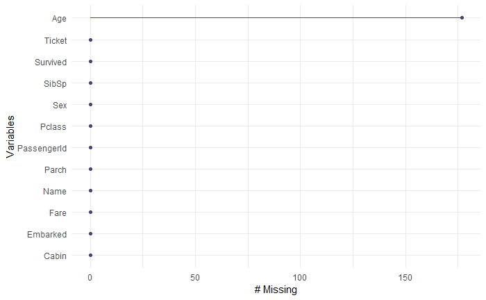

```r
gg_miss_var(train)
```

```r
summary(train$Age)
```

```
   Min. 1st Qu.  Median    Mean 3rd Qu.    Max.    NA's
   0.42   20.12   28.00   29.70   38.00   80.00     177
```

The variable “Age” has 177 missing variables. In estimating survival using Age, they will be excluded as they couldnt be estimated using available information.

So the next thing will be exploratory data analysis. It will be useful to understand the makeup pf the dataset.

```r
summary(train)
```

```
  PassengerId       Survived          Pclass
 Min.   :  1.0   Min.   :0.0000   Min.   :1.000
 1st Qu.:223.5   1st Qu.:0.0000   1st Qu.:2.000
 Median :446.0   Median :0.0000   Median :3.000
 Mean   :446.0   Mean   :0.3838   Mean   :2.309
 3rd Qu.:668.5   3rd Qu.:1.0000   3rd Qu.:3.000
 Max.   :891.0   Max.   :1.0000   Max.   :3.000

                                    Name         Sex           Age
 Abbing, Mr. Anthony                  :  1   female:314   Min.   : 0.42
 Abbott, Mr. Rossmore Edward          :  1   male  :577   1st Qu.:20.12
 Abbott, Mrs. Stanton (Rosa Hunt)     :  1                Median :28.00
 Abelson, Mr. Samuel                  :  1                Mean   :29.70
 Abelson, Mrs. Samuel (Hannah Wizosky):  1                3rd Qu.:38.00
 Adahl, Mr. Mauritz Nils Martin       :  1                Max.   :80.00
 (Other)                              :885                NA's   :177
     SibSp           Parch             Ticket         Fare
 Min.   :0.000   Min.   :0.0000   1601    :  7   Min.   :  0.00
 1st Qu.:0.000   1st Qu.:0.0000   347082  :  7   1st Qu.:  7.91
 Median :0.000   Median :0.0000   CA. 2343:  7   Median : 14.45
 Mean   :0.523   Mean   :0.3816   3101295 :  6   Mean   : 32.20
 3rd Qu.:1.000   3rd Qu.:0.0000   347088  :  6   3rd Qu.: 31.00
 Max.   :8.000   Max.   :6.0000   CA 2144 :  6   Max.   :512.33
                                  (Other) :852
         Cabin     Embarked
            :687    :  2
 B96 B98    :  4   C:168
 C23 C25 C27:  4   Q: 77
 G6         :  4   S:644
 C22 C26    :  3
 D          :  3
 (Other)    :186
```

```r
str(train)
```

```
'data.frame':   891 obs. of  12 variables:
 $ PassengerId: int  1 2 3 4 5 6 7 8 9 10 ...
 $ Survived   : int  0 1 1 1 0 0 0 0 1 1 ...
 $ Pclass     : int  3 1 3 1 3 3 1 3 3 2 ...
 $ Name       : Factor w/ 891 levels "Abbing, Mr. Anthony",..: 109 191 358 277 16 559 520 629 417 581 ...
 $ Sex        : Factor w/ 2 levels "female","male": 2 1 1 1 2 2 2 2 1 1 ...
 $ Age        : num  22 38 26 35 35 NA 54 2 27 14 ...
 $ SibSp      : int  1 1 0 1 0 0 0 3 0 1 ...
 $ Parch      : int  0 0 0 0 0 0 0 1 2 0 ...
 $ Ticket     : Factor w/ 681 levels "110152","110413",..: 524 597 670 50 473 276 86 396 345 133 ...
 $ Fare       : num  7.25 71.28 7.92 53.1 8.05 ...
 $ Cabin      : Factor w/ 148 levels "","A10","A14",..: 1 83 1 57 1 1 131 1 1 1 ...
 $ Embarked   : Factor w/ 4 levels "","C","Q","S": 4 2 4 4 4 3 4 4 4 2 ...
```

From an overview of the dataset provided, the variables that will be essential for this analysis were based on the healthy status of the person, attitude to gender, children and love ones, and position of the individuals on board the ship. These attributes have been codified using the following variables: 1. Age (Age in years); 2.Sex (Gender); 3. Sibsp (Number of siblings or spouses aboard the Titanic); 4.Pclass(Ticket class); 5.Parch (# of parents / children aboard the Titanic); 6.Cabin (Cabin number); 7.embarked (Port of Embarkation); 8.Survival.

Lets look at the data for testing.

```r
dim_desc(test)
```

[output not shown]

```r
str(test)
```

[output not shown]

```r
test[12]<-""
colnames(test)[colnames(test)=="V12"] <- "Survived"
test<-select(test,PassengerId,Survived,Pclass,Name,Sex,Age,SibSp,Parch,Ticket,Fare,Cabin,Embarked)
```

```r
newTrain<-select(train,Survived,Sex,Age,Pclass,SibSp,Cabin,Parch,Embarked)
```

We look at the unique variables to know which variable needs to be grouped for better anlaysis.

```r
unique(newTrain$Sex)
```

```
[1] male   female
Levels: female male
```

```r
unique(newTrain$Pclass)
```

```
[1] 3 1 2
```

```r
unique(newTrain$SibSp)
```

```
[1] 1 0 3 4 2 5 8
```

```r
unique(newTrain$Parch)
```

```
[1] 0 1 2 5 3 4 6
```

```r
unique(newTrain$Embarked)
```

```
[1] S C Q
Levels:  C Q S
```

```r
unique(newTrain$Age)
```

```
 [1] 22.00 38.00 26.00 35.00    NA 54.00  2.00 27.00 14.00  4.00 58.00 20.00
[13] 39.00 55.00 31.00 34.00 15.00 28.00  8.00 19.00 40.00 66.00 42.00 21.00
[25] 18.00  3.00  7.00 49.00 29.00 65.00 28.50  5.00 11.00 45.00 17.00 32.00
[37] 16.00 25.00  0.83 30.00 33.00 23.00 24.00 46.00 59.00 71.00 37.00 47.00
[49] 14.50 70.50 32.50 12.00  9.00 36.50 51.00 55.50 40.50 44.00  1.00 61.00
[61] 56.00 50.00 36.00 45.50 20.50 62.00 41.00 52.00 63.00 23.50  0.92 43.00
[73] 60.00 10.00 64.00 13.00 48.00  0.75 53.00 57.00 80.00 70.00 24.50  6.00
[85]  0.67 30.50  0.42 34.50 74.00
```

```r
unique(newTrain$Cabin)
```

```
  [1]                 C85             C123            E46
  [5] G6              C103            D56             A6
  [9] C23 C25 C27     B78             D33             B30
 [13] C52             B28             C83             F33
 [17] F G73           E31             A5              D10 D12
 [21] D26             C110            B58 B60         E101
 [25] F E69           D47             B86             F2
 [29] C2              E33             B19             A7
 [33] C49             F4              A32             B4
 [37] B80             A31             D36             D15
 [41] C93             C78             D35             C87
 [45] B77             E67             B94             C125
 [49] C99             C118            D7              A19
 [53] B49             D               C22 C26         C106
 [57] C65             E36             C54             B57 B59 B63 B66
```

[output cut: 23 more lines]

By looking at the data, both Age and Cabin could be grouped to provide reasonable number of level for analysis. Age could be group in ages of 10 until Age 60 which will exist as one age group (There were only 22 people aged above 60).

```r
#Grouping for age
newTrain$Age_cut<-cut(train$Age,c(0,10,20,30,40,50,60,100))
table(factor(newTrain$Age_cut))
```

[output not shown]

Grouping for cabin

```r
newTrain$Cabin_cut<-newTrain$Cabin
newTrain$Cabin_cut<-substring(newTrain$Cabin_cut, 1, 1)
table(factor(newTrain$Cabin_cut))
```

[output not shown]

There are 687 in a cabin without a number in from of it. We can assume the lowest cabin of the ship. For this exercise, we will call that cabin “Lx”

```r
levels(newTrain$Cabin_cut)<-c(levels(newTrain$Cabin_cut), "Lx")
newTrain$Cabin_cut[newTrain$Cabin_cut==""]<-"Lx"
table(factor(newTrain$Cabin_cut))
```

[output not shown]

```r
par(mfrow=c(4,3))
cabinsurvival<-table(newTrain$Survived,newTrain$Cabin_cut)
cabinsurvival2 <- melt(cabinsurvival)
names(cabinsurvival2)[1]<-"Survived"
names(cabinsurvival2)[2]<-"Name_of_Cabin"
names(cabinsurvival2)[3]<-"Passengers_Survival_by_Cabin"
ggplot(cabinsurvival2,aes(x = Name_of_Cabin, y =Passengers_Survival_by_Cabin,fill =Survived))+geom_bar(position = "fill",stat = "identity") +scale_y_continuous(labels = percent_format())
cabinsurvival
```

[output not shown]